# STAT 380 Final Project

#### Correlation Plot

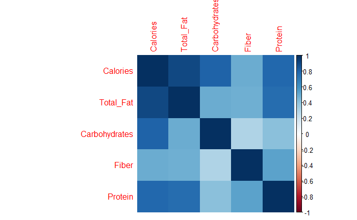

```r
cr <- cor(joined_data[, 2:6])
corrplot(cr, method = 'color')
```

```r
rm('cr')
```

#### Calories Vs Total Fat Scatter Plot

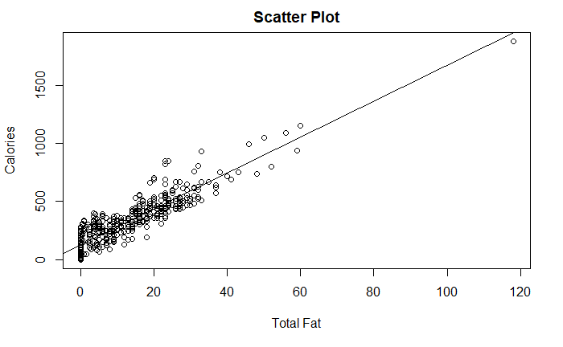

```r
plot(joined_data$Total_Fat, joined_data$Calories,
     main = "Scatter Plot", xlab = "Total Fat", ylab = "Calories")
abline(lm(joined_data$Calories ~ joined_data$Total_Fat))
```

#### Colries vs Protein Density Map

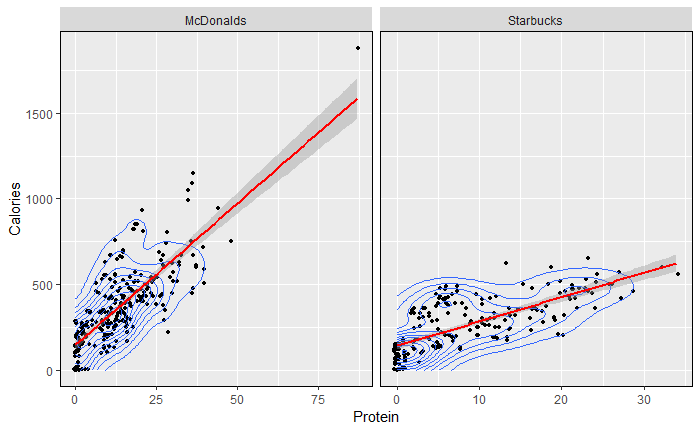

```r
options(repr.plot.height = 4, repr.plot.width = 6)
ggplot(joined_data, aes(y = Calories, x = Protein)) +
  geom_jitter(size = 1) +
  stat_density2d() +
  geom_smooth(method = 'lm', colour = 2) +
  facet_wrap( ~ Brand, scales = "free_x") +
  theme(panel.border = element_rect(colour = 1, fill = NA))
```

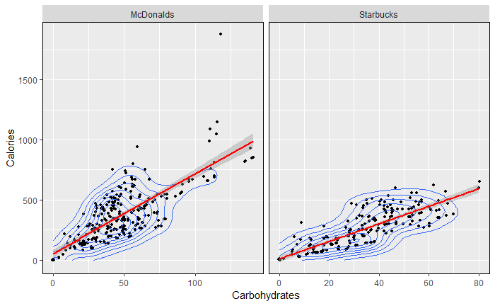

```r
options(repr.plot.height = 4, repr.plot.width = 6)
ggplot(joined_data, aes(y = Calories, x = Carbohydrates)) +
  geom_jitter(size = 1) +
  stat_density2d() +
  geom_smooth(method = 'lm', colour = 2) +
  facet_wrap( ~ Brand, scales = "free_x") +
  theme(panel.border = element_rect(colour = 1, fill = NA))
```

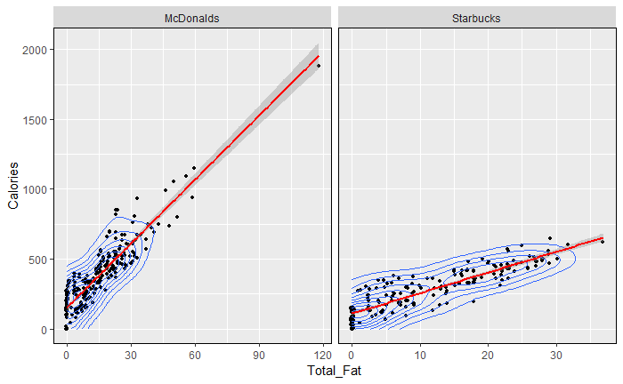

```r
options(repr.plot.height = 4, repr.plot.width = 6)
ggplot(joined_data, aes(y = Calories, x = Total_Fat)) +
  geom_jitter(size = 1) +
  stat_density2d() +
  geom_smooth(method = 'lm', colour = 2) +
  facet_wrap( ~ Brand, scales = "free_x") +
  theme(panel.border = element_rect(colour = 1, fill = NA))
```

### Model Training

#### Splitting the dataset

```r
split <- sample.split(joined_data$Calories, SplitRatio = 0.80)
train <- subset(joined_data, split == "TRUE")
test <- subset(joined_data, split == "FALSE")
```

#### Linear Regression Model

```r
lm_model <- lm(Calories ~ Total_Fat + Protein + Carbohydrates, data = train)
summary(lm_model)
```

```
Call:
lm(formula = Calories ~ Total_Fat + Protein + Carbohydrates,
    data = train)

Residuals:
    Min      1Q  Median      3Q     Max
-36.801  -3.197   0.788   3.865  27.937

Coefficients:
              Estimate Std. Error t value Pr(>|t|)
(Intercept)   -0.78805    0.72659  -1.085    0.279
Total_Fat      9.00809    0.04760 189.227   <2e-16 ***
Protein        4.00040    0.05596  71.485   <2e-16 ***
Carbohydrates  3.97237    0.01676 236.950   <2e-16 ***
---
Signif. codes:  0 ‘***’ 0.001 ‘**’ 0.01 ‘*’ 0.05 ‘.’ 0.1 ‘ ’ 1

Residual standard error: 7.185 on 368 degrees of freedom
Multiple R-squared:  0.999, Adjusted R-squared:  0.999
F-statistic: 1.213e+05 on 3 and 368 DF,  p-value: < 2.2e-16
```

#### Plots to explain the model

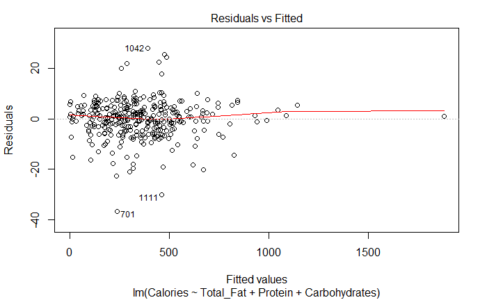

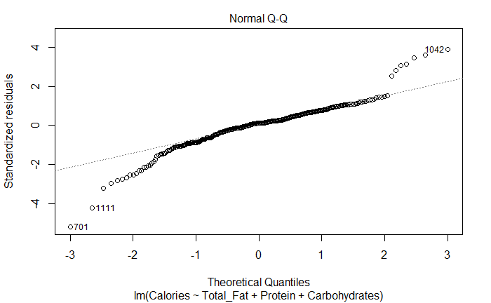

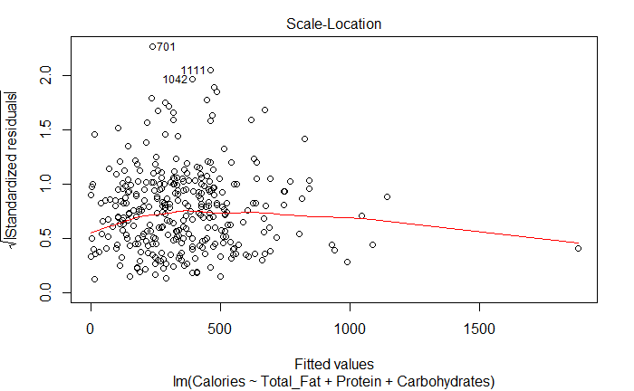

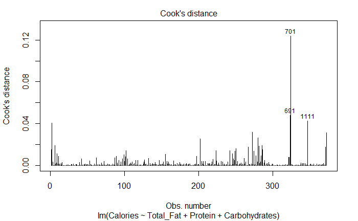

```r
plot(lm_model, which = 1:4)
```

#### Predictions vs Actual

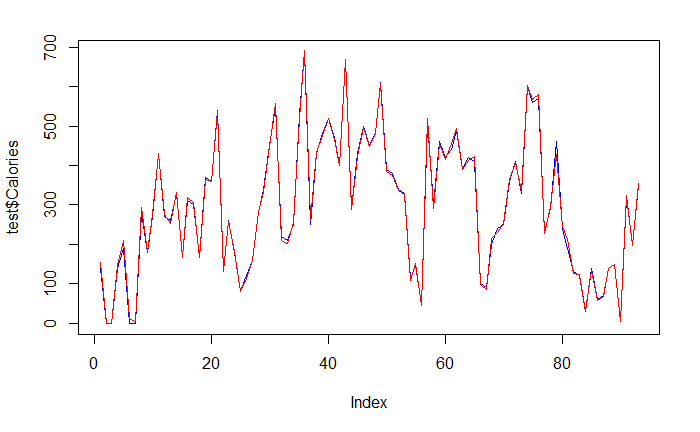

```r
predictions <- predict(lm_model, test)
plot(test$Calories, type = "l", lty = 1.8, col = "blue")
lines(predictions, type = "l", col = "red")
```

#### Future Predictions

```r
predict(lm_model, data.frame(Total_Fat = 20, Protein = 18, Carbohydrates = 33))
```

```
       1
382.4693
```

#### Decision Tree

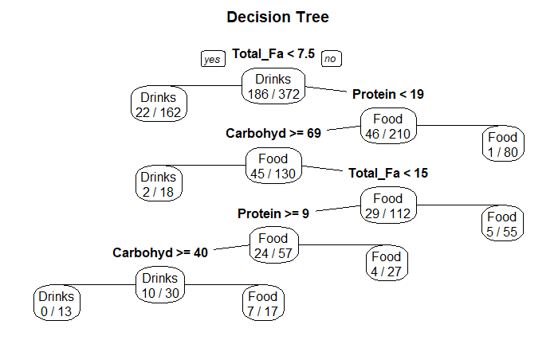

```r
dt_model <- rpart(Type ~ Calories + Total_Fat + Protein + Carbohydrates,
                  data = train)
prp(dt_model, type = 1, extra = 3, main = "Decision Tree")
```

```r
predictions <- data.frame(data = factor(predict(dt_model, test, type="class")),
                          type = "prediction")
real <- data.frame(data = factor(test$Type), type = "real")
conf_data <- rbind(predictions, real)

# Check if the levels are identical
identical(levels(conf_data[conf_data$type == "prediction", 1]),
          levels(conf_data[conf_data$type == "real", 1]))
```

```
[1] TRUE
```

```r
confusionMatrix(conf_data[conf_data$type == "prediction", 1],
                conf_data[conf_data$type == "real",1],
                dnn = c("Prediction", "Reference"))
```

```
Confusion Matrix and Statistics

          Reference
Prediction Drinks Food
    Drinks     42   10
    Food        6   35

               Accuracy : 0.828
                 95% CI : (0.7357, 0.8983)
    No Information Rate : 0.5161
    P-Value [Acc > NIR] : 3.339e-10

                  Kappa : 0.6546

 Mcnemar's Test P-Value : 0.4533

            Sensitivity : 0.8750
            Specificity : 0.7778
         Pos Pred Value : 0.8077
         Neg Pred Value : 0.8537
             Prevalence : 0.5161
         Detection Rate : 0.4516
   Detection Prevalence : 0.5591
      Balanced Accuracy : 0.8264

       'Positive' Class : Drinks
```

```r
# Freeing up Memory of redundant data
rm('predictions', 'real', 'conf_data', 'split', 'test', 'train')
```

### Plot Starbucks Food (Calories and Fat)

```r
# Red line shows recomended meal amount of Calories for food
# Blue line shows MAX recomended daily amount of Fat for Food


# http://my.clevelandclinic.org/health/articles/11208-fat-what-you-need-to-know

plot(Calories~Total_Fat,
     ylab = 'Calories in Starbucks Food',
     xlab = 'Total Fat in Starbucks Food',
     main = 'Caleries vs Total Fat for Starbucks Food',
     data = sbux_f)
abline(v = 22, col = 'blue')
```

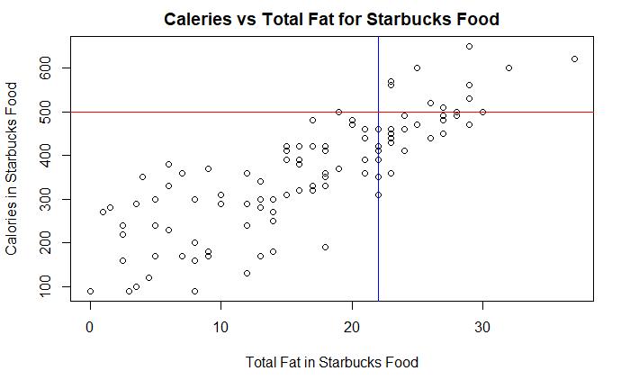

```r
abline(h = 500, col = 'red')
```

```r
sbux_f %>%
  select(Item, Calories, Total_Fat) %>%
  filter(Calories >= 500, Total_Fat >= 22) %>%
  count(Item) %>%
  ungroup() %>%
  arrange(desc(n))
```

| Item | n |
| --- | --- |
| Chicken Artichoke on Ancient Grain Flatbread | 1 |
| Green Goddess Avocado Salad | 1 |
| Lentils & Vegetable Protein Bowl with Brown Rice | 1 |
| PB&J Protein Box | 1 |
| Roasted Turkey & Dill Havarti Sandwich | 1 |
| Sausage Cheddar & Egg Breakfast Sandwich | 1 |
| Seared Steak & Cheddar Sandwich | 1 |
| Smoked Mozzarella & Roasted Pepper Sandwich | 1 |
| Spicy Chorizo Monterey Jack & Egg Breakfast Sandwich | 1 |
| Strawberries & Jam Sandwich | 1 |

[output cut: 3 more lines]

```r
# Unhealthiest Option
sbux_f %>%
  select(Item, Calories, Total_Fat) %>%
  filter(Calories >= 600, Total_Fat >= 28) %>%
  count(Item) %>%
  ungroup() %>%
  arrange(desc(n))
```

| Item | n |
| --- | --- |
| Green Goddess Avocado Salad | 1 |
| Lentils & Vegetable Protein Bowl with Brown Rice | 1 |
| Roasted Turkey & Dill Havarti Sandwich | 1 |

```r
# Green Goddess Avocado Salad
# Lentils & Vegetable Protein Bowl with Brown Rice
# Roasted Turkey & Dill Havarti Sandwich
```

### Plot Starbucks Drink (Calories and Total Fat)

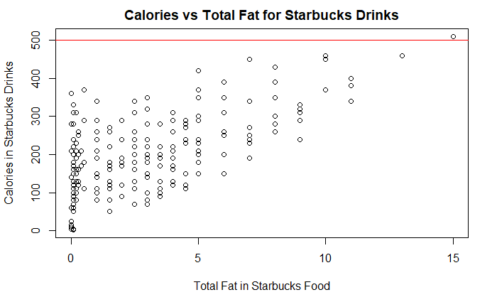

```r
# Red line shows recomended meal amount of Calories for food

# http://my.clevelandclinic.org/health/articles/11208-fat-what-you-need-to-know

plot(Calories~Total_Fat,
     ylab = 'Calories in Starbucks Drinks',
     xlab = 'Total Fat in Starbucks Food',
     main = 'Calories vs Total Fat for Starbucks Drinks',
     data = drinks_expanded)
abline(h = 500, col = 'red')
```

### Plot Starbucks Drink (Sugars and Total Fat)

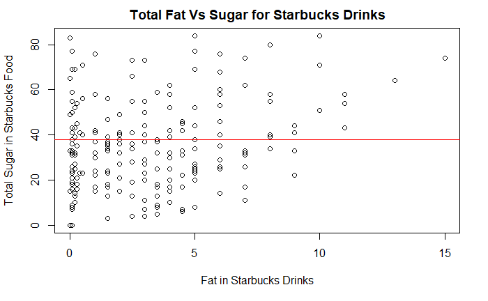

```r
# Red line shows MAX recomended meal amount of sugar for food

# http://sugarscience.ucsf.edu/the-growing-concern-of-overconsumption.html

plot(Sugars~Total_Fat,
     xlab = 'Fat in Starbucks Drinks',
     ylab = 'Total Sugar in Starbucks Food',
     main = 'Total Fat Vs Sugar for Starbucks Drinks',
     data = drinks_expanded)
abline(h = 38, col = 'red')
```

### Plot Starbucks Drink (Sugars and Caffine)

```r
# Blue line Max recomendation of sugar
# Red line Max recomendation of caffine


sudo<-drinks_expanded %>%
  mutate(clean_caff=as.numeric(as.character(drinks_expanded$Caffeine)))
sudo[is.na(sudo)]<-0

plot(clean_caff ~ Sugars,
     ylab = 'Caffeine in Starbucks Drinks',
     xlab = 'Sugar in Starbucks Food',
     main = 'Total Fat Vs Sugar for Starbucks Drinks',
     data = sudo)
abline(h = 400, col = 'red')
```

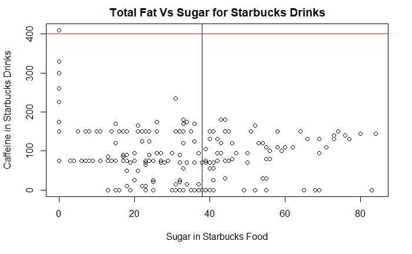

```r
abline(v = 38, col = 'blue')
```

```r
#Venti Coffee
sudo %>%
  select(Beverage_category, clean_caff) %>%
  filter(clean_caff >= 400)
```

| Beverage_category | clean_caff |
| --- | --- |
| Coffee | 410 |

```r
sudo %>%
  select(Beverage_category, Sugars) %>%
  filter(Sugars >= 38) %>%
  count(Beverage_category) %>%
  ungroup() %>%
  arrange(desc(n))
```

| Beverage_category | n |
| --- | --- |
| Frappuccino Blended Coffee | 33 |
| Signature Espresso Drinks | 19 |
| Tazo Tea Drinks | 15 |
| Frappuccino Blended Crme | 9 |
| Classic Espresso Drinks | 4 |
| Frappuccino Light Blended Coffee | 4 |
| Smoothies | 3 |

```r
sudo_sugar <- sudo %>%
  select(Beverage_category, Sugars) %>%
  filter(Sugars >= 38)

# % of drinks have higher than rated sugar
length(sudo_sugar[, 1]) / length(drinks_expanded$Beverage_category)
```

```
[1] 0.3990826
```

```r
# Worst drinks ordered by violation of sugar contents
# Frappuccino Blended Coffee
# Signature Espresso Drinks
# Tazo Tea Drinks
```

#### Distribution of the variables in each of the datasets

Drinks expanded dataset

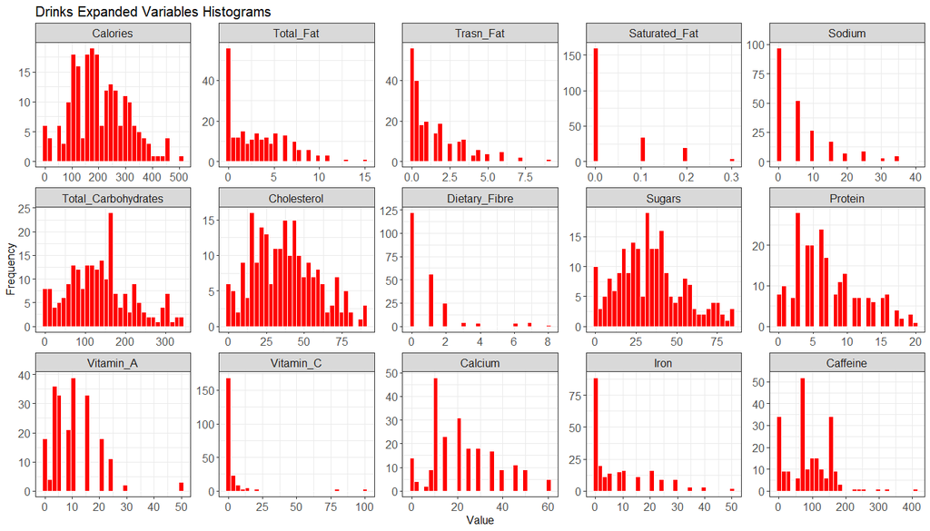

```r
drinks_expanded %>%
    select(-contains("Beverage")) %>%
    mutate(dummy = 1) %>%
    melt(id = 'dummy') %>%
    mutate(value = as.numeric(value)) %>%
    ggplot(aes(value)) +
    geom_histogram(color = 'white', fill = 'red') +
    facet_wrap(~variable, scales = 'free', ncol = 5) +
    theme_bw() +
    labs(x = 'Value', y = 'Frequency',
         title = 'Drinks Expanded Variables Histograms')+
    theme(
        legend.text = element_text(size = 11),
        legend.position = "top",
        legend.title = element_blank(),
        axis.text.x = element_text(size = 12),
        axis.text.y = element_text(size = 12),
        axis.title.x = element_text(size = 12),
        axis.title.y = element_text(size = 12),
        strip.text.y = element_text(size = 12),
        strip.text.x = element_text(size = 12),
        plot.title = element_text(size = 15))
```

###Food dataset

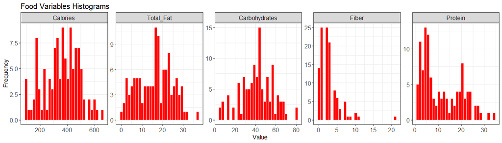

```r
sbux_f %>%
    select(-contains('Item')) %>%
    select(-contains('Type')) %>%
    mutate(dummy = 1) %>%
    melt(id = 'dummy') %>%
    mutate(value = as.numeric(value)) %>%
    ggplot(aes(value)) +
    geom_histogram(color = 'white',fill = 'red') +
    facet_wrap(~variable, scales = 'free', ncol = 5) +
    theme_bw() +
    labs(x = 'Value', y = 'Frequency',
         title = 'Food Variables Histograms') +
    theme(
        legend.text = element_text(size = 11),
        legend.position = "top",
        legend.title = element_blank(),
        axis.text.x = element_text(size = 12),
        axis.text.y = element_text(size = 12),
        axis.title.x = element_text(size = 12),
        axis.title.y = element_text(size = 12),
        strip.text.y = element_text(size = 12),
        strip.text.x = element_text(size = 12),
        plot.title = element_text(size = 15))
```

### Supervised learning

Fit linear model to predict number of Calories in a drink based on other variables such as Total_Fat, Trans_Fat. Sugars etc. 5 folds cross validation Used and will use `MAPE` (mean average error percentage) as the perforamce metrics. Once we have the `MAPE` for each fold, I will simply take the average of all folds and this will be the final `MAPE`

```r
# Randomly shuffle the data, set seed to produce the same resultss
# Additionaly remove first 3 columns which contains the Beverage descriptions
drinks_expanded <-
  drinks_expanded[sample(nrow(drinks_expanded)), ] %>%
  select(-contains("Beverage"))

# Create 5 equally size folds
K <- 5
folds <- cut(seq(1, nrow(drinks_expanded)), breaks = K, labels = FALSE)

# Perform 5 folds cross validation
MAPE <- c()
for(i in 1:K){
    index <- which(folds == i,arr.ind = TRUE)
    train <- drinks_expanded[-index, ]
    test <- drinks_expanded[index, ]
    model <- lm(Calories ~., data = train)
    prediction <- predict(model, test)
    MAPE[i] <- abs(test$Calories / prediction - 1)
}

paste0('MAPE for 5 folds: ', round(mean(MAPE) * 100, 2), '%')
```

```
[1] "MAPE for 5 folds: 2.4%"
```

### Unspurviesd learning

for the unspurviesd part, I will use the sbux_f dataset. We will use “Hierarchical Clustering” in order to find clusters of similiar sbux_fs based on `Calories`, `Fat`, `Carb`, `Fiver` and `Protein`

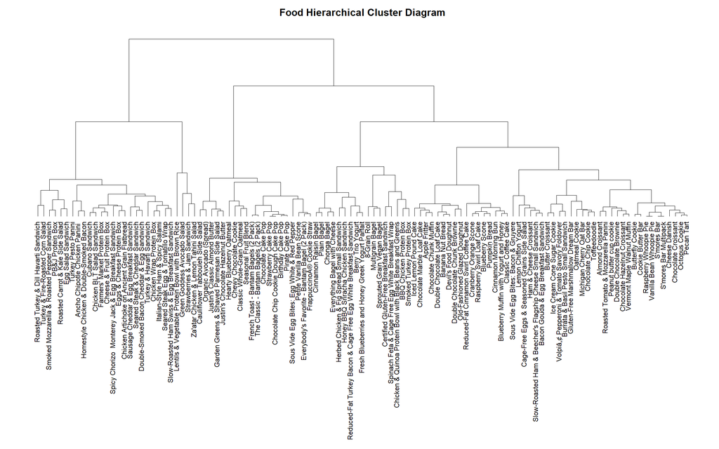

```r
# remove the sbux_f column
df <- sbux_f %>% select(-Item, -Type)
# set sbux_f column as the row names
rownames(df) <- sbux_f$Item

# scale the data and create distance metrics using euclidean distance.
dd <- dist(scale(df), method = "euclidean")

# fit hierarchical clustering using "ward.D2" method
hc <- hclust(dd, method = "ward.D2")

# plot the results
par(cex = 1, mar = c(2, 2, 4, 1))
plot(hc, hang = -1, cex = 1.4, xlab = "", sub="",
     axes=FALSE, ylab = '',
     main='Food Hierarchical Cluster Diagram', cex.main = 2)
```

### Simulation

Simulation using sampling with replacement, bootstrap, simulates 365 days for eating 3 meals and drinking 3 drinks a day, examines total sugar, caleries, fat, carbohydrates, and caffine. Histograms show distribution of nutrion facts per day where the red line is the recomendation by the Federal Goverment, citation is first line.

```r
starbucks_order <- function(food_size = 1, drink_size = 1){
  food_samp <- sample(sbux_f, food_size, replace = TRUE)
  drink_samp <- sample(drinks_expanded, drink_size, replace = TRUE)

  total_sugar <- sum(drink_samp$Sugars)
  total_caffine <- sum(drink_samp$Caffeine)
  total_calories <- sum(food_samp$Calories) + sum(drink_samp$Calories)
  total_fat <- sum(food_samp$Fat) + sum(drink_samp$Total_Fat)
  total_carbo <- sum(food_samp$Carb) + sum(drink_samp$Total_Carbohydrates)

  # Index 1 Sugar
  # Index 2 Calories
  # Index 3 Fat
  # Index 4 Carbohydrates
  # Index 5 Caffeine
  return(c(total_sugar, total_calories, total_fat, total_carbo, total_caffine))
}

food_orders <- 3
drink_orders <- 3
n <- 365
final_sim <- do(n) * starbucks_order(food_orders, drink_orders)
head(final_sim)
```

|  | V1 | V2 | V3 | V4 | V5 |
| --- | --- | --- | --- | --- | --- |
| 1 | 60 | 1520 | 14.5 | 456 | 185 |
| 2 | 131 | 1970 | 19.0 | 665 | 225 |
| 3 | 89 | 1610 | 8.5 | 426 | 370 |
| 4 | 147 | 2060 | 14.0 | 782 | 335 |
| 5 | 90 | 1525 | 6.5 | 405 | 480 |
| 6 | 143 | 1710 | 9.5 | 792 | 390 |

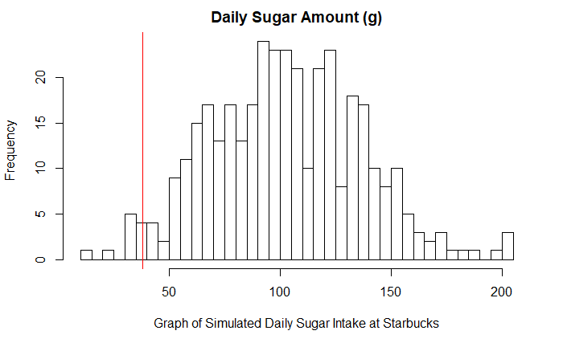

```r
hist(final_sim[, 1],
     breaks = 30,
     xlab = 'Graph of Simulated Daily Sugar Intake at Starbucks',
     main = 'Daily Sugar Amount (g)')
abline(v = 38, col = 'red')
```

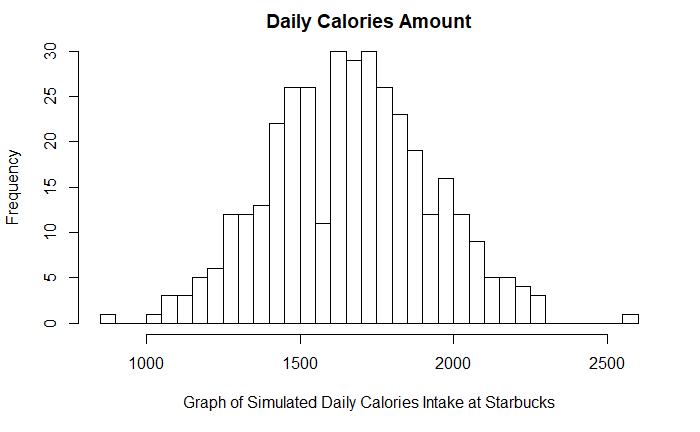

```r
hist(final_sim[, 2],
     breaks = 30,
     xlab = 'Graph of Simulated Daily Calories Intake at Starbucks',
     main = 'Daily Calories Amount')
```

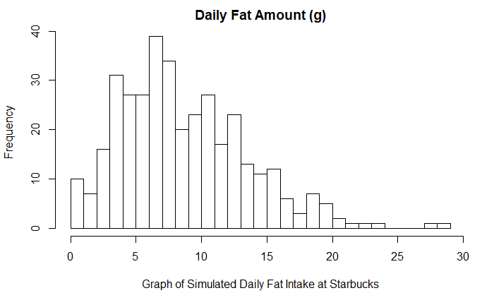

```r
hist(final_sim[, 3],
     breaks = 30,
     xlab = 'Graph of Simulated Daily Fat Intake at Starbucks',
     main = 'Daily Fat Amount (g)')
abline(v = 65, col = 'red')
```

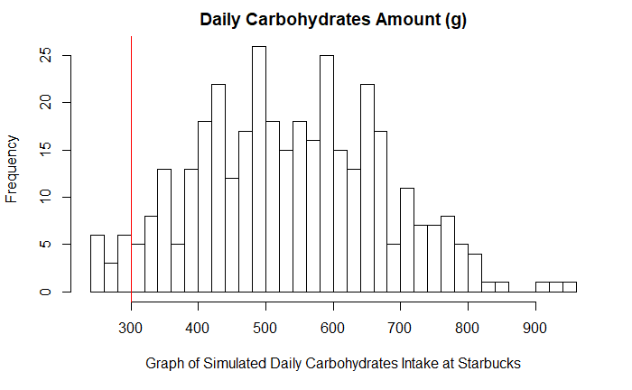

```r
hist(final_sim[, 4],
     breaks = 30,
     xlab = 'Graph of Simulated Daily Carbohydrates Intake at Starbucks',
     main = 'Daily Carbohydrates Amount (g)')
abline(v = 300, col = 'red')
```

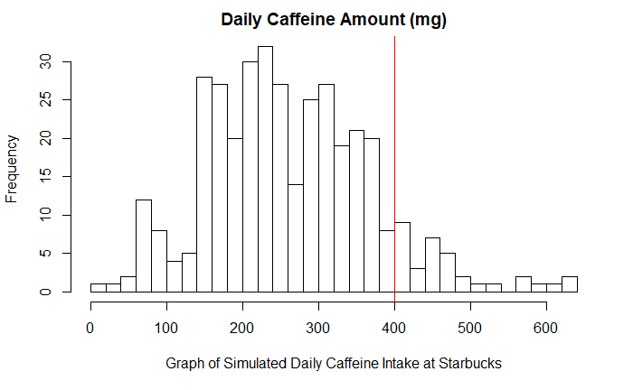

```r
hist(final_sim[, 5],
     breaks = 30,
     xlab = 'Graph of Simulated Daily Caffeine Intake at Starbucks',
     main = 'Daily Caffeine Amount (mg)')
abline(v = 400, col = 'red')
```

```r
cat('Sugar\n')
```

```
Sugar
```

```r
mean(final_sim[,1])
```

```
[1] 103.2877
```

```r
cat('Calories\n')
```

```
Calories
```

```r
mean(final_sim[,2])
```

```
[1] 1669.523
```

```r
cat('Fat\n')
```

```
Fat
```

```r
mean(final_sim[,3])
```

```
[1] 8.716712
```

```r
cat('Carbohydrates\n')
```

```
Carbohydrates
```

```r
mean(final_sim[,4])
```

```
[1] 538.1918
```

```r
cat('Caffine\n')
```

```
Caffine
```

```r
mean(final_sim[,5])
```

```
[1] 263.589
```